# Author : Farhad Ahmad Qureshi

# Introduction

Prosper is a marketplace lending platform. Borrower’s send requests for loans and investors then decide how much to lend. Borrower rates are usually lesser than financial institutions such as banks and multiple investors contribute towards the loan reducing the risk of impacting only one investor if the borrower defaults.

## Dataset

This data set contains 113,937 loans with 81 variables on each loan, including loan amount, borrower rate (or interest rate), current loan status, borrower income, borrower employment status, borrower credit history, and the latest payment information.

The reason I selected this dataset was because I never worked on a data set like this and I wanted to see what factors lead borrowers to become defaulters and what factors lead an investor to contribute towards a loan. I will first explore the dataset and see distribution of a few selected variables that I found interesting. This will be the univariate analysis. Following this, I will explore relation of these variables with being a default non-default (good) borrower. This will be the bivariate analysis. At the end I will use these plots to to add more information in the multivariate plots section.

### The exploratory analysis will begin with the univariate plots using the following variables:

## Distribution of variables selected for analysis.

```
## 'data.frame':    113937 obs. of  17 variables:
##  $ ListingCreationDate       : chr  "2007" "2014" "2007" "2012" ...
##  $ Term                      : int  36 36 36 36 36 60 36 36 36 36 ...
##  $ LoanStatus                : Factor w/ 12 levels "Cancelled","Chargedoff",..: 3 4 3 4 4 4 4 4 4 4 ...
##  $ BorrowerAPR               : num  0.165 0.12 0.283 0.125 0.246 ...
##  $ BorrowerState             : Factor w/ 52 levels "","AK","AL","AR",..: 7 7 12 12 25 34 18 6 16 16 ...
##  $ Occupation                : Factor w/ 68 levels "","Accountant/CPA",..: 37 43 37 52 21 43 50 29 24 24 ...
##  $ EmploymentStatus          : Factor w/ 9 levels "","Employed",..: 9 2 4 2 2 2 2 2 2 2 ...
##  $ IsBorrowerHomeowner       : Factor w/ 2 levels "False","True": 2 1 1 2 2 2 1 1 2 2 ...
##  $ CreditScoreRangeUpper     : int  659 699 499 819 699 759 699 719 839 839 ...
##  $ InquiriesLast6Months      : int  3 3 0 0 1 0 0 3 1 1 ...
##  $ DebtToIncomeRatio         : num  0.17 0.18 0.06 0.15 0.26 0.36 0.27 0.24 0.25 0.25 ...
##  $ IncomeRange               : Factor w/ 8 levels "$0","$1-24,999",..: 4 5 7 4 3 3 4 4 4 4 ...
##  $ StatedMonthlyIncome       : num  3083 6125 2083 2875 9583 ...
##  $ LoanOriginalAmount        : int  9425 10000 3001 10000 15000 15000 3000 10000 10000 10000 ...
##  $ LP_CustomerPayments       : num  11396 0 4187 5143 2820 ...
##  $ Investors                 : int  258 1 41 158 20 1 1 1 1 1 ...
##  $ LoanMonthsSinceOrigination: int  78 0 86 16 6 3 11 10 3 3 ...
```

# Univariate Plots Section

## Loan Status.

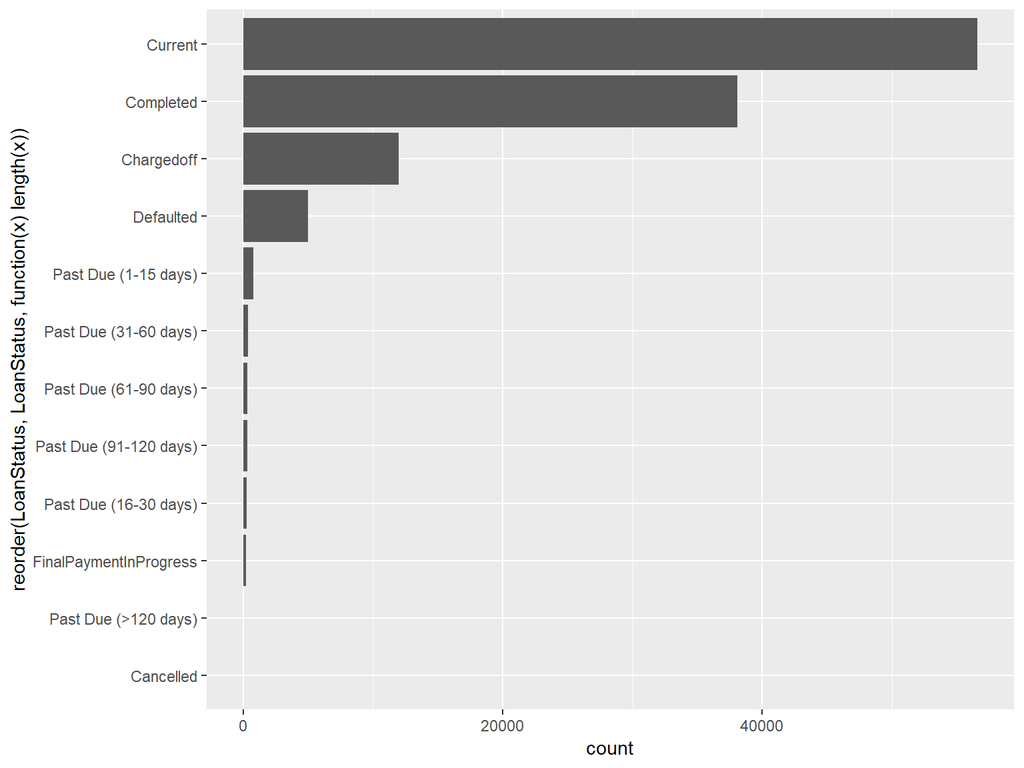

### Checking the distribution of default and good standing borrowers:

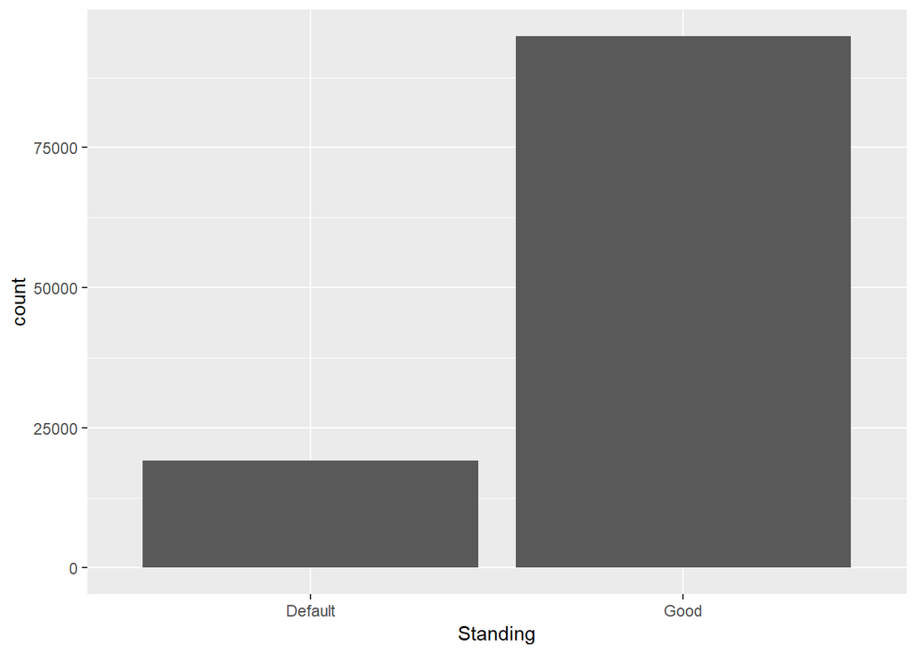

> Defaulters are usually less than in number from those in Good standing (including those who have completed their loans).

## Creation Date

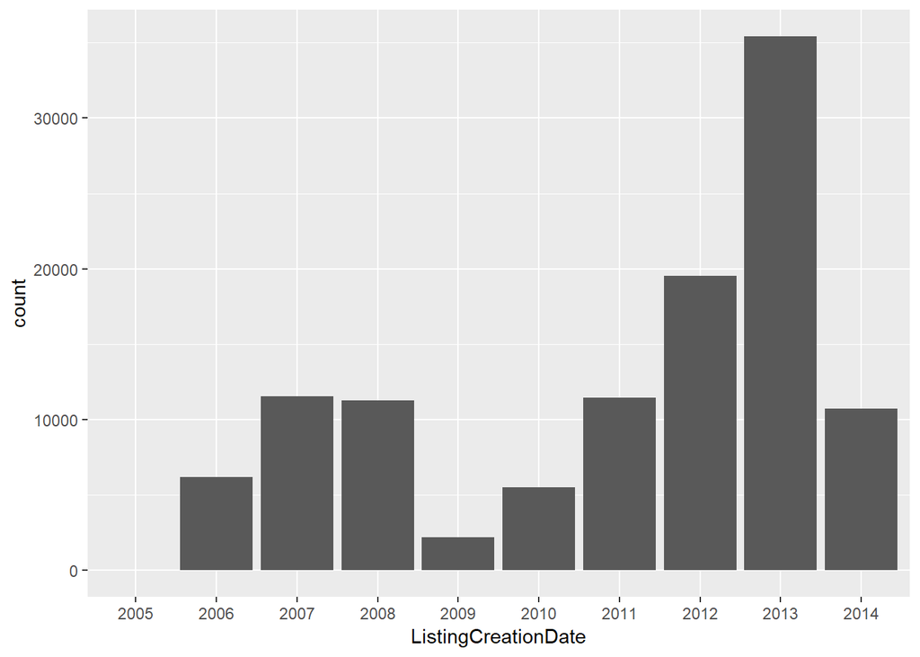

## Loan Term

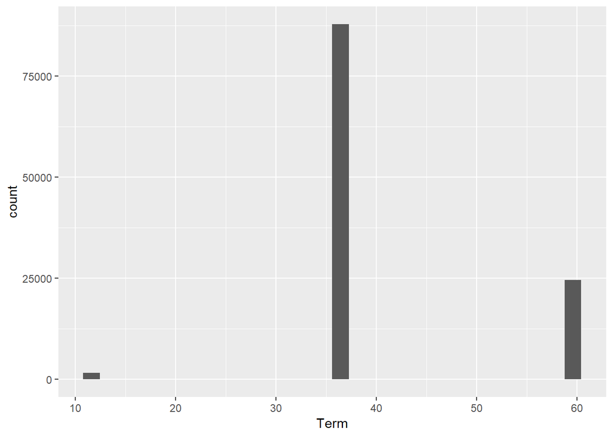

Majority of the borrowers are given loan for a term of 36 months. The second highest being the 60 months term.

## Borrower APR

This is used instead of Borrower rate since it contains any additional service charges as well.

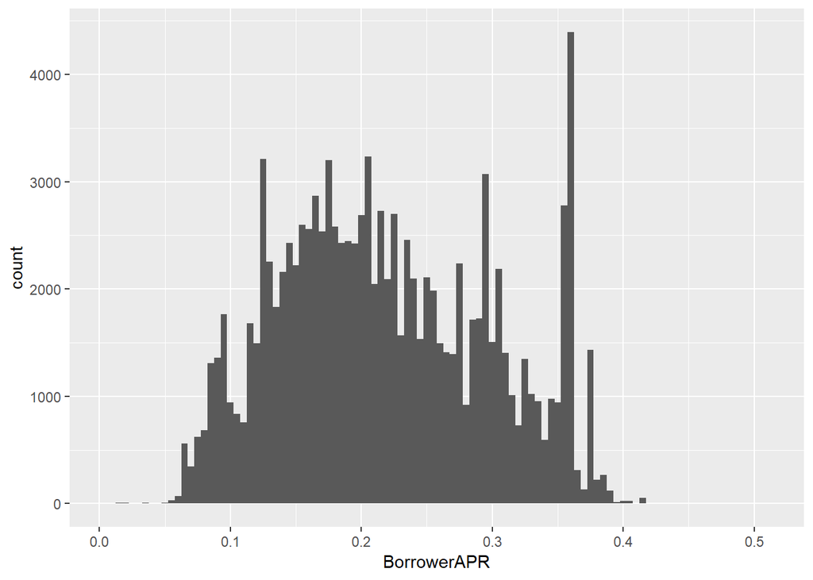

```
##    Min. 1st Qu.  Median    Mean 3rd Qu.    Max.    NA's
## 0.00653 0.15629 0.20976 0.21883 0.28381 0.51229      25
```

The lowest of Borrower’s APR is 0.00653 and the maximum is upto 0.51. The typical range of this is between 0.05 to 0.38

## LoanMonthsSinceOrigination

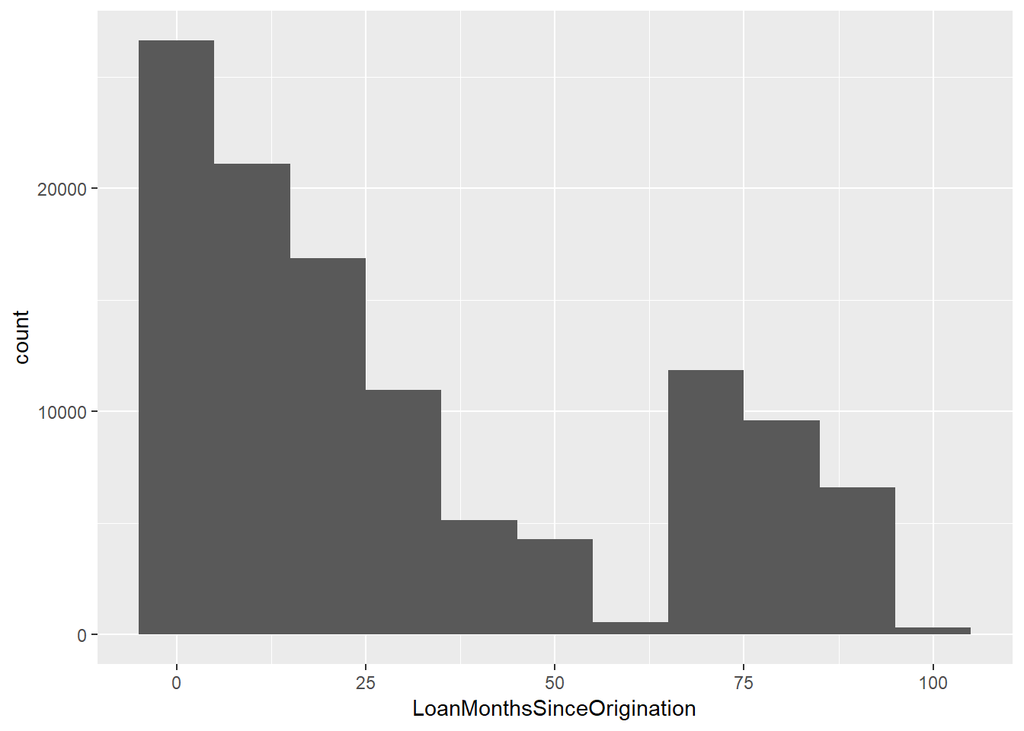

Distribution of loans with respect to the months since they were originated.Most loans are between 0 - 25. This will be an interesting feature later to investigate default borrowers.

## Borrower State

I was interested to see the demographics for each state and if there are any states with high number of borrowers.

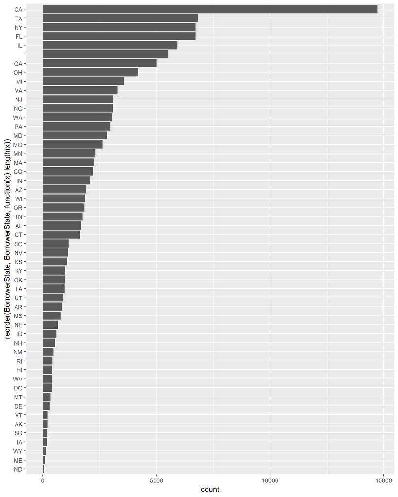

Majority of loans are from California. This might be because of its large population. This causes the plot to be right skewed so we will take this into consideration later and log transform the y axis.7 States have count more than or equal to 5000

## Employment Status

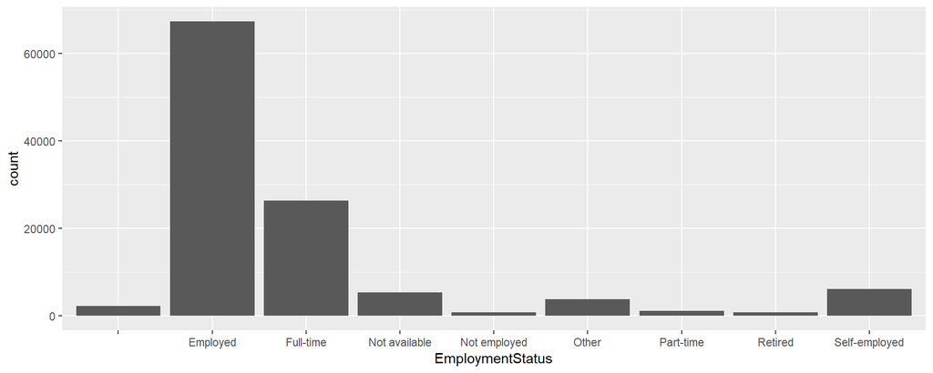

Majority of the loans go to the the employed classes.

## IsBorrowerHomeowner

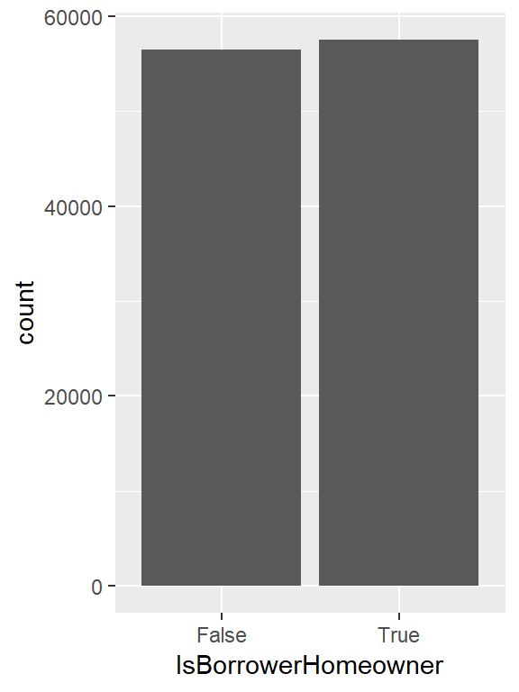

Doesnt really matter if a borrower owns a house or not count is almost the same for both.

## Investors

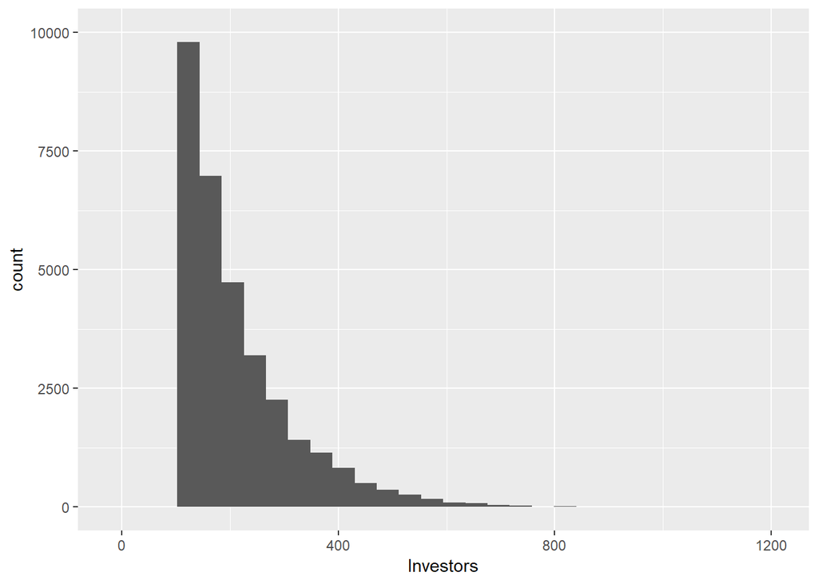

Distribution of investors majority being under 100 but it would be interesting to see the loan amount and how much investors contribute.

```
##    Min. 1st Qu.  Median    Mean 3rd Qu.    Max.
##    1.00    2.00   44.00   80.48  115.00 1189.00
```

Median investors for the data is 44.

## CreditScoreRangeUpper

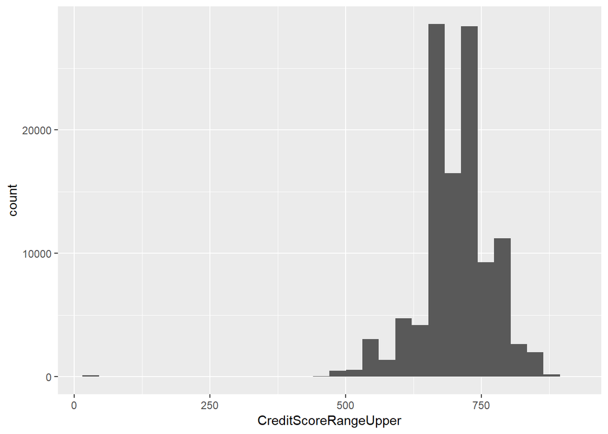

As expected most borrowers have high scores (peak around 700).

```
##    Min. 1st Qu.  Median    Mean 3rd Qu.    Max.    NA's
##    19.0   679.0   699.0   704.6   739.0   899.0     591
```

For upper range we see median rating is in the Good category as per the experience or FICO rating used by Prosper.

## InquiriesLast6Months

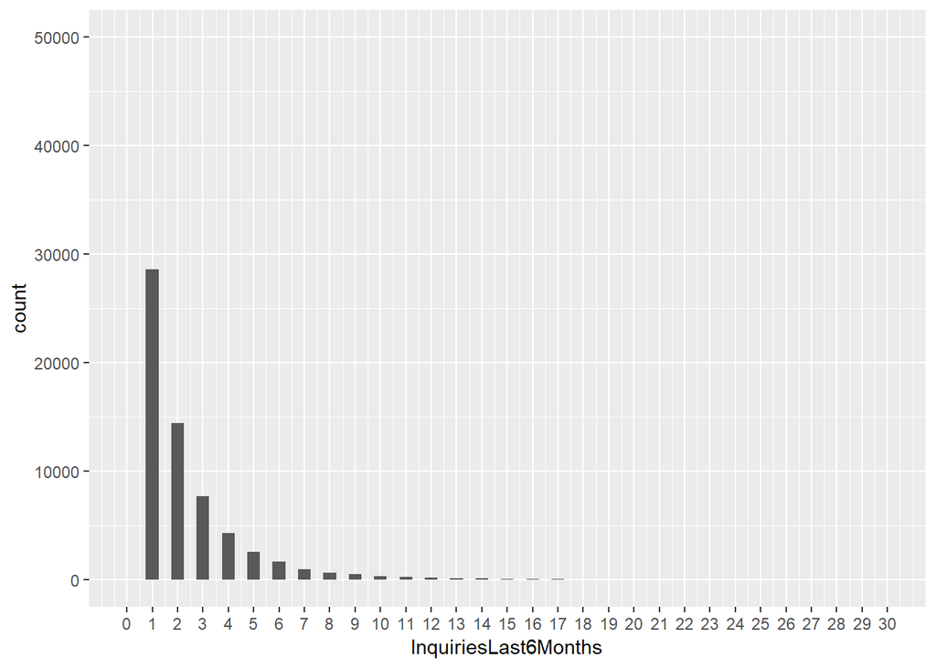

Most borrowers had inquiries under 5 which as mentioned on their website is one of the criteria to give loans but there are outliers here as well.

## DebtToIncomeRatio (DTI)

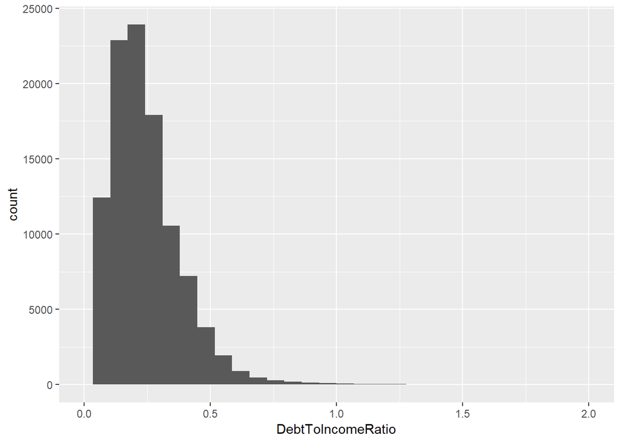

Debt to income ratio of majority of the masses s between 0 to 0.5 which is one of the criteria they follow to lend. However I do see outliers!

## IncomeRange

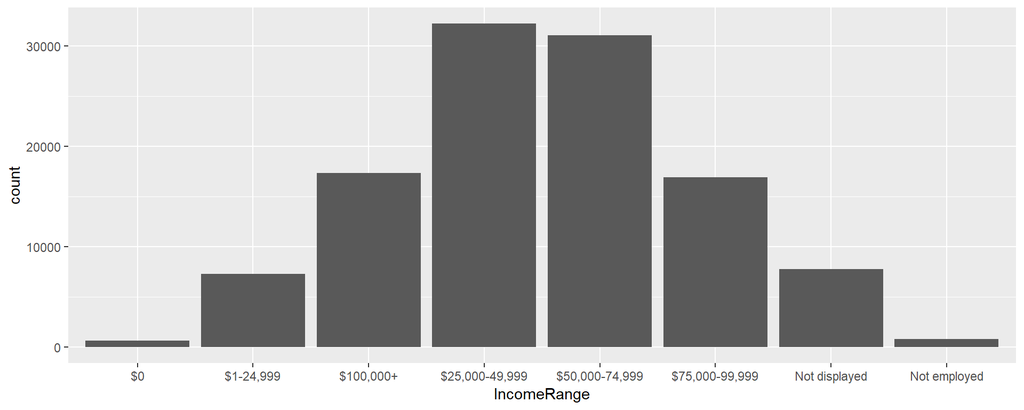

Most of the loans given are for borrower’s within the range of 25k - 100k.

## StatedMonthlyIncome

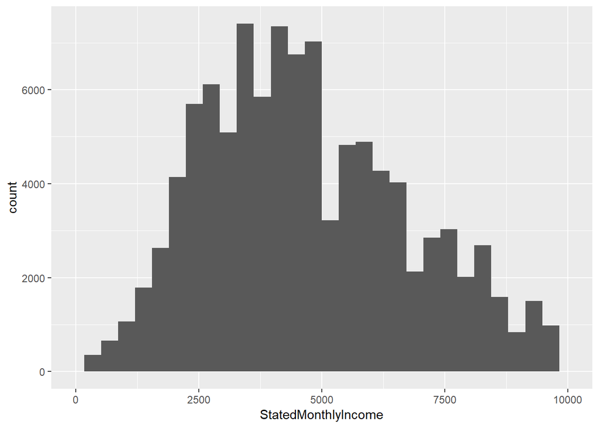

There were outliers so checking monthly payments withing $0 - 10000 only.

## LoanOriginalAmount

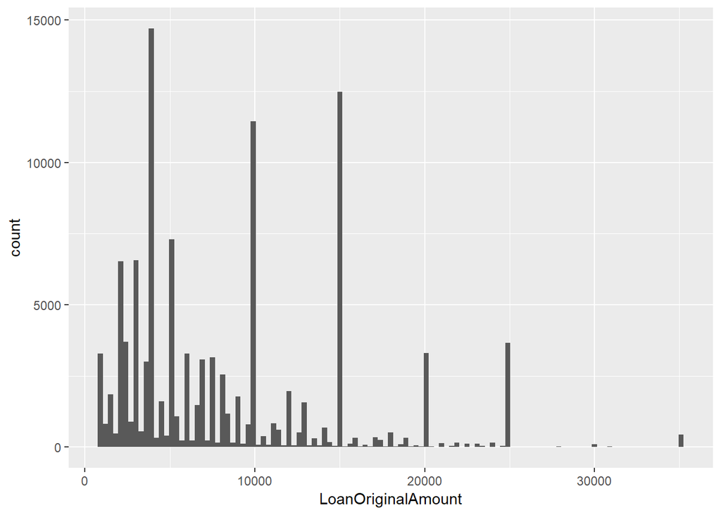

```
##    Min. 1st Qu.  Median    Mean 3rd Qu.    Max.
##    1000    4000    6500    8337   12000   35000
```

Minimum amount lent is 1000 and max is 35000.

## LP_CustomerPayments

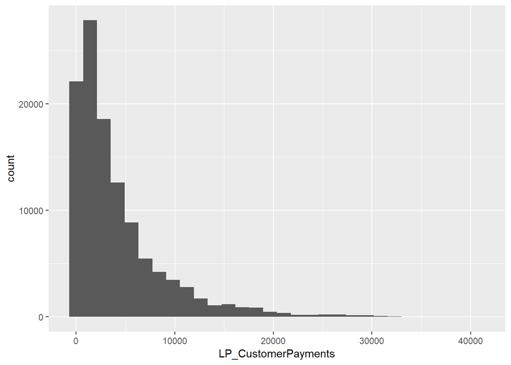

Right skewed distribution. Most payments are between 0 to 10000. A summary of the payments made by borrowers:

```
##     Min.  1st Qu.   Median     Mean  3rd Qu.     Max.
##    -2.35  1005.76  2583.83  4183.08  5548.40 40702.39
```

## Occupation

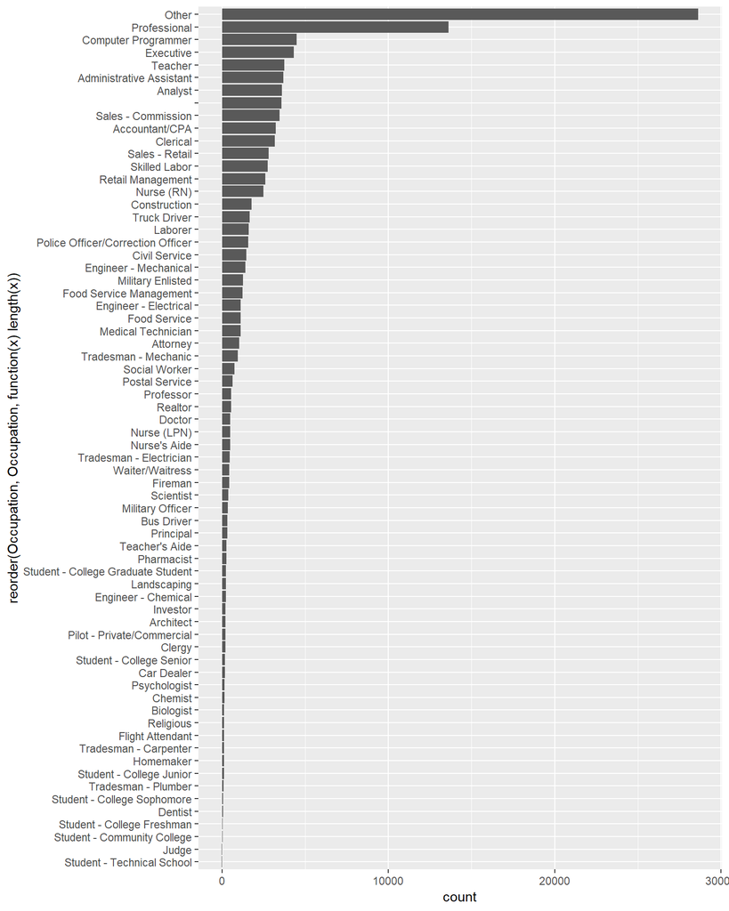

Occupation by loan count.

# Summary of Univariate Analysis.

### What is/are the main feature(s) of interest in your dataset?

The main feature of interest is the LoanStatus variable that contains following categories:

Cancelled

Chargedoff

Completed

Current

Defaulted

FinalPaymentInProgress

Past Due ( 120 days)

Past Due (1-15 days)

Past Due (16-30 days)

Past Due (31-60 days)

Past Due (61-90 days)

Past Due (91-120 days)

It will be important to see what causes a borrower to become a defaulter. After doing some research the categorieschargedoff along with defaulted and past dues are all considered to be the defaulted borrowers and will be referred to as defaulters from now.

The main feature of interest would therefore be to investigate the variables associated with being a defaulter.

The main variables that will be used to investigate this are.

Term

BorrowerAPR

InquiriesLast6Months

DebtToIncomeRatio

IncomeRange

EmploymentStatus

CreditScoreRangeUpper

StatedMonthlyIncome

ListingCreationDate

The following will be used to see other trends within the dataset such as investors strategies to lend to borrowers and payments made by borrowers as compared to the original loan amount.

BorrowerState

LP_CustomerPayments

Investors

Occupation

IsBorrowerHomeowner

LoanOriginalAmount

LoanMonthsSinceOrigination

### Did you create any new variables from existing variables in the dataset?

A new variable is created for the Default borrower using the LoanStatus variable.Listing creation year variable is also created from the original date format.

### Of the features you investigated, were there any unusual distributions? Most of the loans given are for borrower’s within the range of 25k - 100k. However I do see a few borrower’s

who have 0$ income. Not sure what that means but I also see a few in not employed (might be students). Most of the loans are given for 36 months.

# Bivariate Plots Section

## ListingCreationDate vs Standing

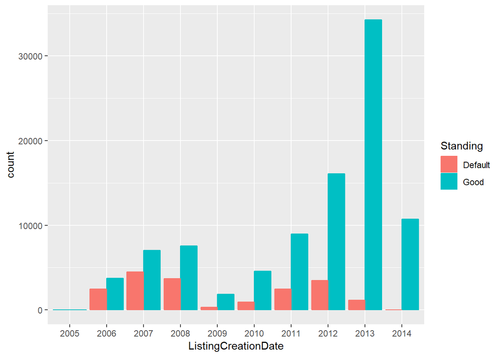

The number of loans are low during 2005 - 20111. Defaulters are mostly in 2007, the year before the financial crisis. Maybe they borrowed on a certain amount and during crisis were not able to pay their loans back. So, financial crisis might be a reason for the skewness seen here in defaulters and should be taken into account.

## BorrowerAPR vs Standing

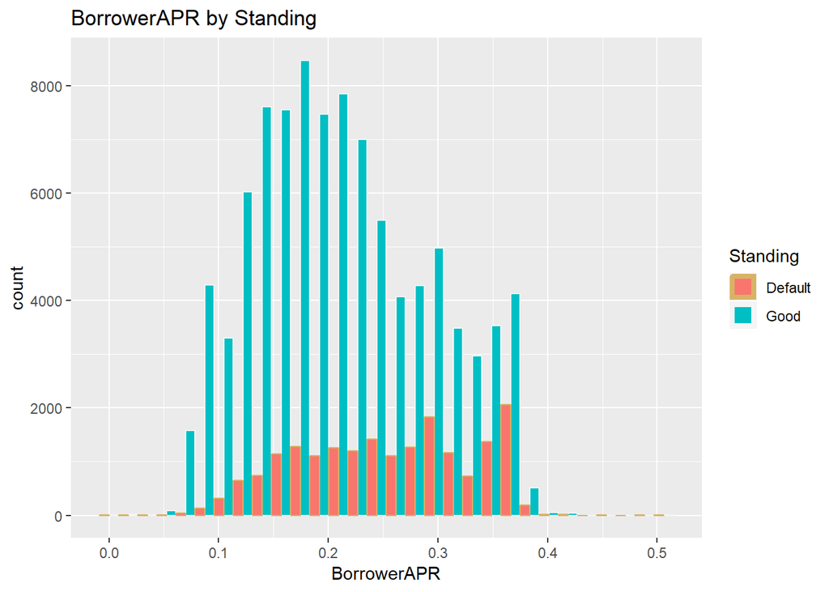

There is some trend seen between high APR and being a defaulter from 0.08 to 0.36 there is a direct relation.

## LoanMonthsSinceOrigination vs Standing

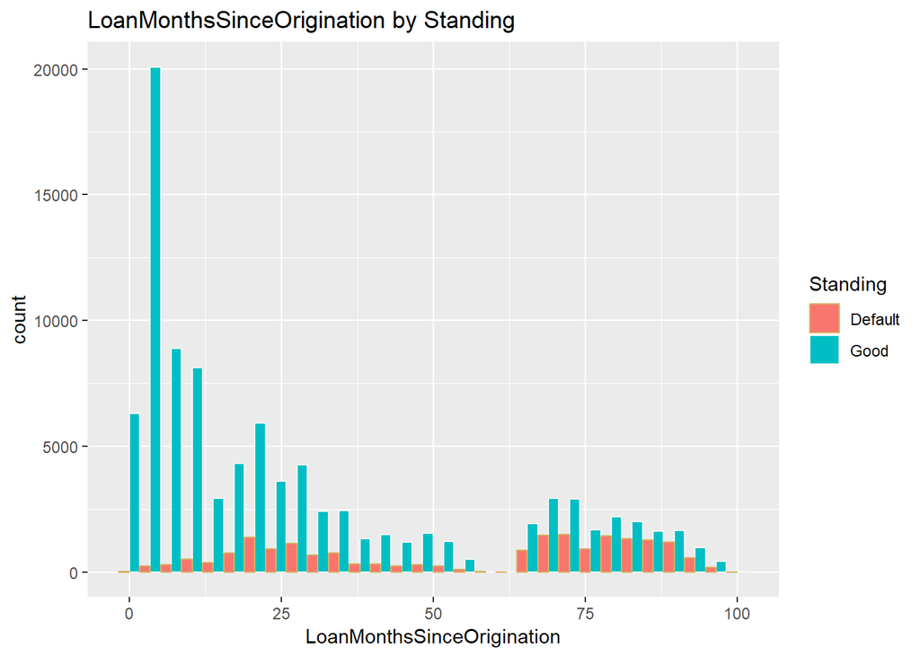

There is a spike around 24 and around 70 months. So I will later check their loan terms to see which loan terms usually go default

## InquiriesLast6Months vs Standing

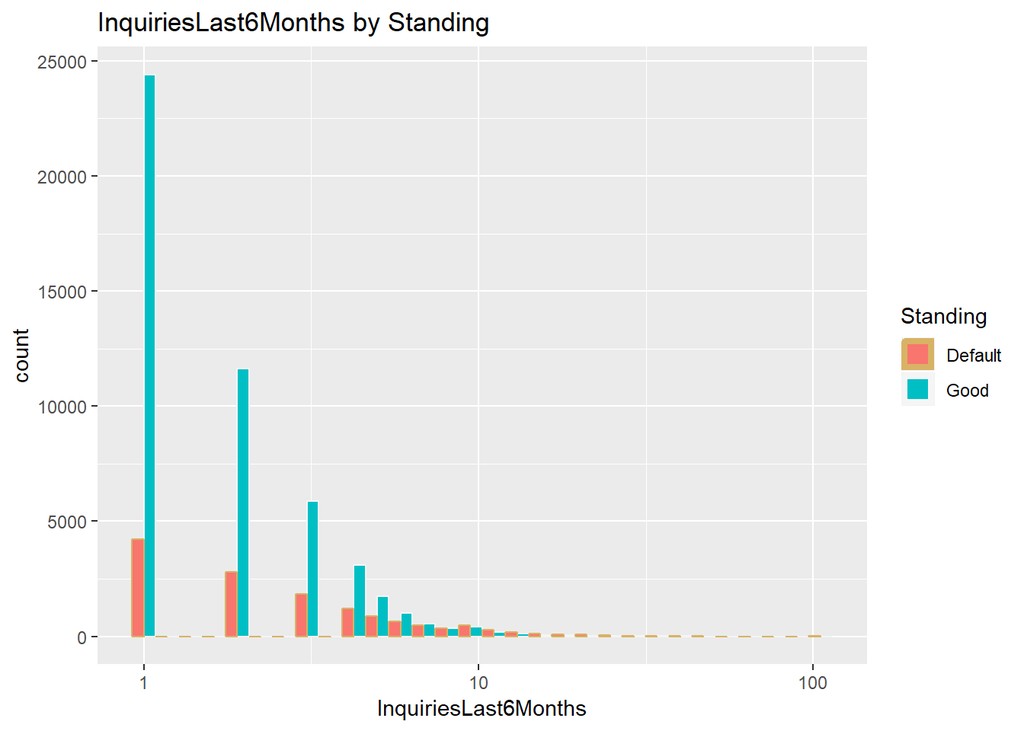

Most of the defaulters have maximum 1 inquiries in last six months. So will check this later if this has something to do with credit score as well.

## DebtToIncomeRatio vs Standing

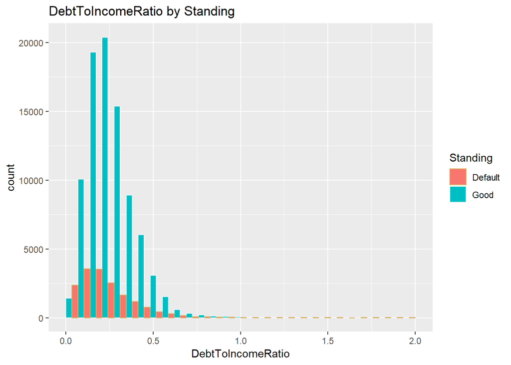

Similar trend of defaulters and those in good standing but obviously different in counts.

## IncomeRange vs Standing

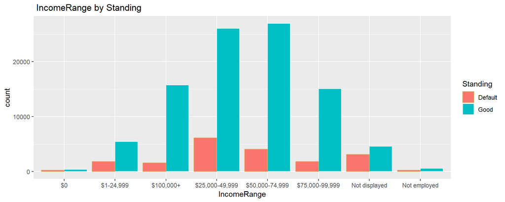

The $25k to 50k range borrower’s have most number of defaulters but this might be due to the fact that this category has majority of borrowers.

## EmploymentStatus VS Standing

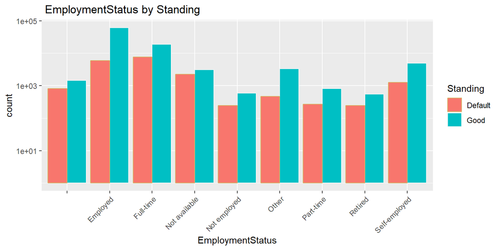

Employment status vs. standing. All categories seem to be having almost equal distribution of defaulter as compared to non defaulters when log transformed the y axis. Data was skewed towards employed borrowers before. Also, defaulters are almost always less than borrowers in each category.

## CreditScoreRangeUpper vs Standing

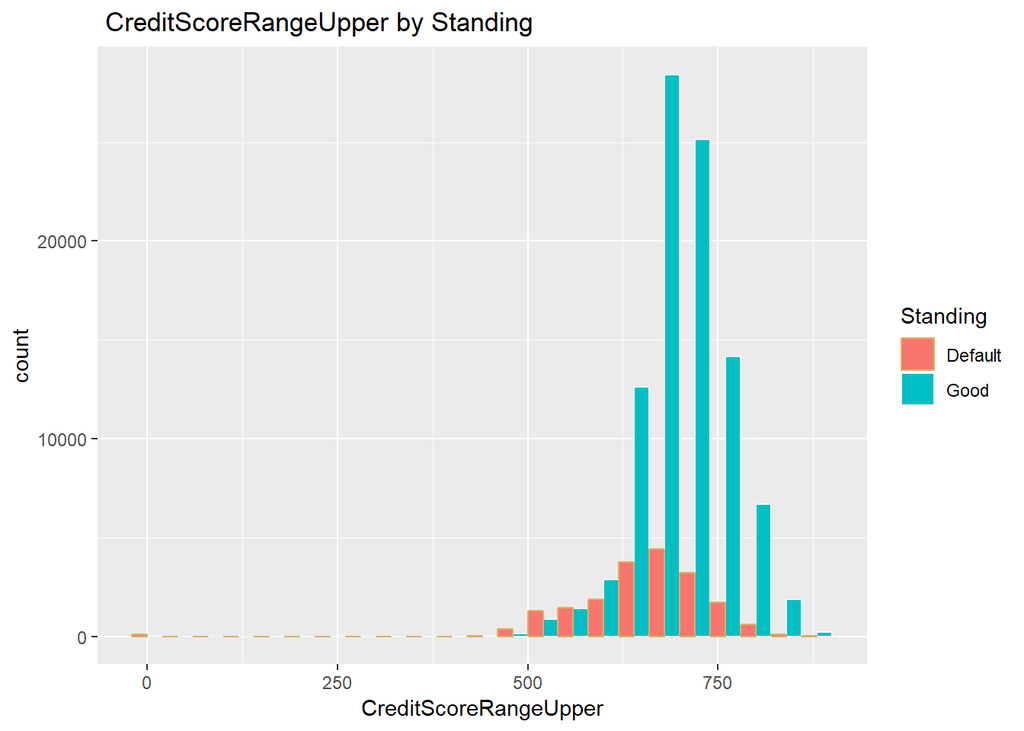

Less defaulters for high credit rating. Most defaulters are in the range 650 - 700 rating.

## BorrowerState vs Standing

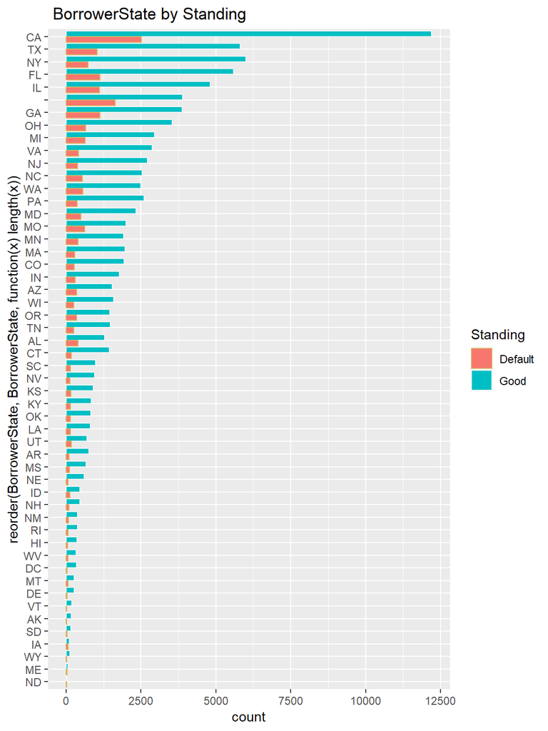

## LoanOriginalAmount by Standing

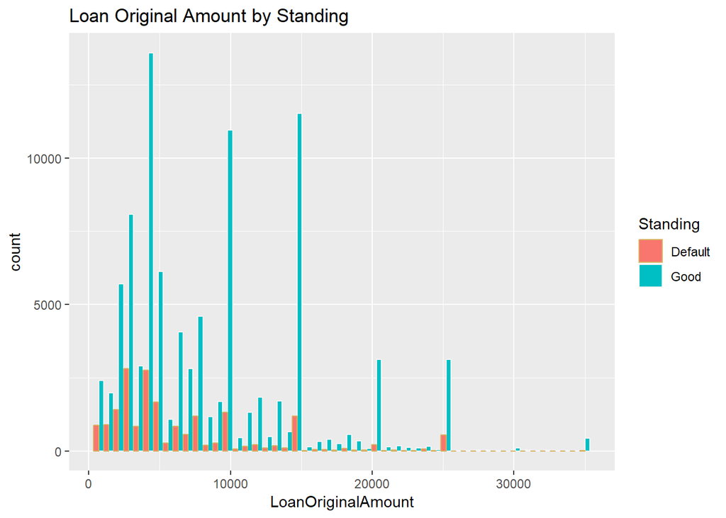

Loan amounts of defaulters is almost always less than the others for the same amount.

## Exploring other trends in the data by seeing interactions between different variables.

## LP_CustomerPayments vs Investors

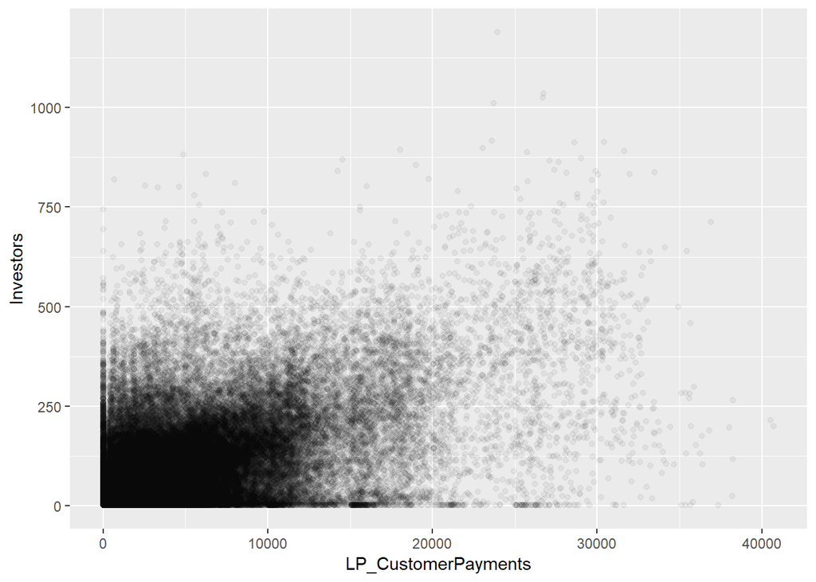

There is some relation between these two so the distribution of good and default borrowers will be interesting to see in multivariate analysis.

## CreditScoreRangeUpper vs InquiriesLast6Months

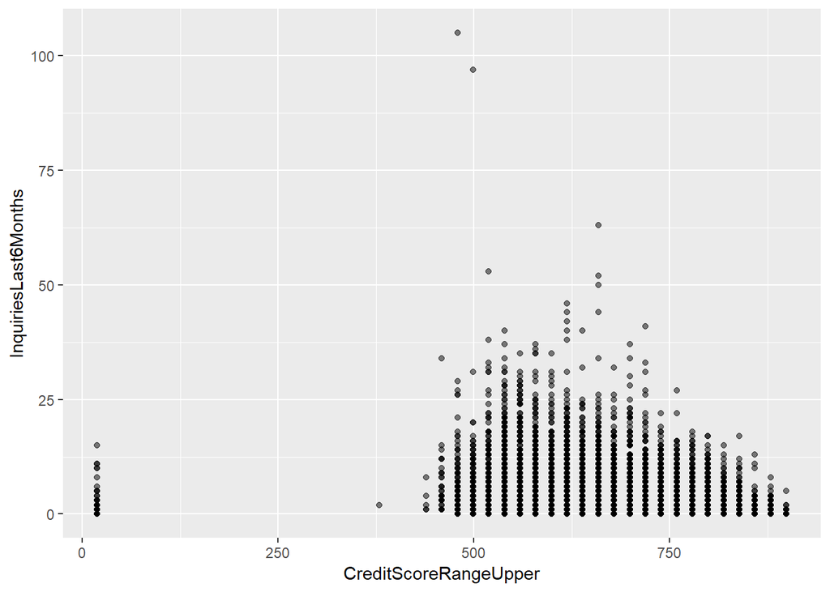

Inquiries increase initially from 450 to 550 but then decreases so it is expected that defaulters are in the lower side of the rating and with more inquiries. Will be checked in multivariate section.

## BorrowerState vs Investors

I was curious to know if investors prefer any states so checking this below:

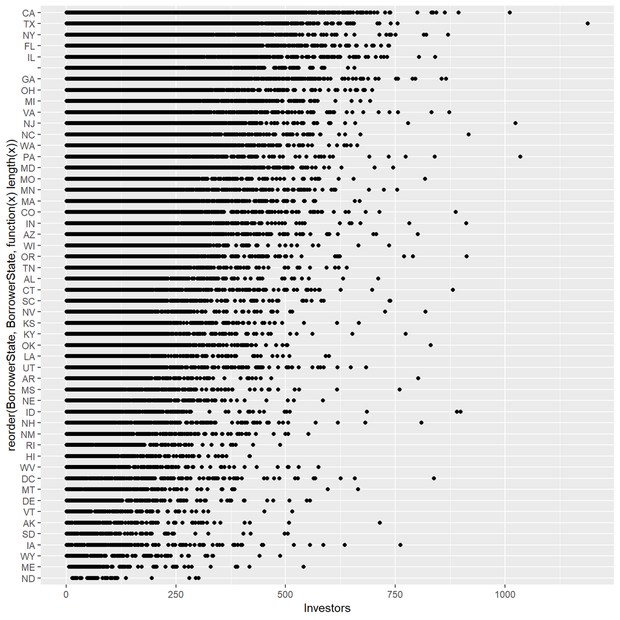

Seeing the relation between investors interest for certain states doesn’t show any specific trends.